# Using Turnstile Data To Forcast Student Worker Staffing

Chad Madding, Shane Weinstock

March 12, 2020

**Deliverables:**

**EDA:**

Saturday March 21 at 11:59pm

**Deliverable:**

1. 3-minute YouTube video: (You can use the same slides but each team member must make the full presentation with all the slides.)
   1. Identify yourself and your team (if applicable).
   2. Describe Data Set / Time Series (Who, What, When, Where, Why and How)
   3. Stationary / Non-Stationary
   4. ACFs and Spectral Densities just to explore
   5. At least 2 candidate ARMA / ARIMA models
      1. The models in factored form or at least separate the stationary and non-stationary factors with standard deviation or variance of the white noise.
      2. AIC
      3. ASE
      4. Visualization of Forecasts with a Practical Horizon.
      5. Strategy / Plans for the rest of the analysis.
2. Submit your slides to 2DS and make sure your video URL is on the Google Doc.

### Describe Data Set

#### Time Series (Who, What, When, Where, Why and How)

```
## Classes 'tbl_df', 'tbl' and 'data.frame':    414155 obs. of  4 variables:
##  $ LDT                  : POSIXct, format: "2019-01-02 06:00:08" "2019-01-02 06:00:33" ...
##  $ Message Type         : chr  "CardAdmitted" "CardAdmitted" "CardAdmitted" "CardAdmitted" ...
##  $ ID#                  : num  4272 1325 2551 253 257 ...
##  $ Secondary Object Name: chr  "DEDM (101.1LB)" "DEDM (101.3LB)" "DEDM (101.1LB)" "DEDM (101.2LB)" ...
```

```
## Classes 'tbl_df', 'tbl' and 'data.frame':    17473 obs. of  17 variables:
##  $ DATE                     : POSIXct, format: "2019-01-01 00:15:00" "2019-01-01 00:35:00" ...
##  $ HourlyAltimeterSetting   : num  30.1 30.1 30.1 30.1 30.1 ...
##  $ HourlyDewPointTemperature: num  37 37 37 37 37 37 37 37 37 37 ...
##  $ HourlyDryBulbTemperature : num  43 42 42 41 41 41 41 41 41 41 ...
##  $ HourlyPrecipitation      : num  NA NA NA NA NA NA NA NA NA NA ...
##  $ HourlyPresentWeatherType : chr  NA NA NA NA ...
##  $ HourlyPressureChange     : logi  NA NA NA NA NA NA ...
##  $ HourlyPressureTendency   : logi  NA NA NA NA NA NA ...
##  $ HourlyRelativeHumidity   : num  81 82 84 86 86 87 86 85 85 85 ...
##  $ HourlySeaLevelPressure   : logi  NA NA NA NA NA NA ...
##  $ HourlySkyConditions      : chr  "CLR:00" "CLR:00" "CLR:00" "CLR:00" ...
##  $ HourlyStationPressure    : num  29.4 29.4 29.4 29.4 29.4 ...
##  $ HourlyVisibility         : num  10 10 10 10 10 10 10 10 10 10 ...
##  $ HourlyWetBulbTemperature : num  40 40 40 39 39 39 39 39 39 39 ...
##  $ HourlyWindDirection      : chr  "330" "340" "350" "350" ...
##  $ HourlyWindGustSpeed      : chr  NA NA "18" "18" ...
##  $ HourlyWindSpeed          : num  9 8 13 10 10 15 14 15 16 20 ...
##  - attr(*, "problems")=Classes 'tbl_df', 'tbl' and 'data.frame': 57 obs. of  5 variables:
##   ..$ row     : int  1258 1535 1536 1537 1999 2859 4093 4251 4281 4281 ...
##   ..$ col     : chr  "HourlyVisibility" "HourlyDewPointTemperature" "HourlyDewPointTemperature" "HourlyDewPointTemperature" ...
##   ..$ expected: chr  "a double" "no trailing characters" "no trailing characters" "no trailing characters" ...
##   ..$ actual  : chr  "*" "s" "s" "s" ...
##   ..$ file    : chr  "'2085029.csv'" "'2085029.csv'" "'2085029.csv'" "'2085029.csv'" ...
```

**Data Cleaning**

Compactly Display the Structure of the data.

We had to clean up the hours for the merge.

```r
#Group hours
SMUSwipe$TempTime <- format(SMUSwipe$LDT,"%Y-%m-%d")
SMUSwipe$Hour <-ifelse(SMUSwipe$Hour <= '04','04',
                      ifelse(SMUSwipe$Hour <= '08','08',
                      ifelse(SMUSwipe$Hour <=  12, 12,
                      ifelse(SMUSwipe$Hour <=  16, 16,
                      ifelse(SMUSwipe$Hour <=  20, 20,
                      ifelse(SMUSwipe$Hour <=  24, 24))))))
SMUSwipe$TempTime<-paste(SMUSwipe$TempTime, SMUSwipe$Hour, sep=" ")
```

We had to clean up the hours for the merge.

```r
#Group all ID swipes by 15 minutes (quarter hour)
#Create a TempTime in HourlyWeather to merge Temperature data
HourlyWeather$TempTime <- format(HourlyWeather$DATE,"%Y-%m-%d")
HourlyWeather$Hour <- format(HourlyWeather$DATE,"%H")

HourlyWeather$Hour <-ifelse(HourlyWeather$Hour <= '04','04',
                      ifelse(HourlyWeather$Hour <= '08','08',
                      ifelse(HourlyWeather$Hour <=  12, 12,
                      ifelse(HourlyWeather$Hour <=  16, 16,
                      ifelse(HourlyWeather$Hour <=  20, 20,
                      ifelse(HourlyWeather$Hour <=  24, 24))))))
HourlyWeather$TempTime<-paste(HourlyWeather$TempTime, HourlyWeather$Hour, sep=" ")
#Recreate the Hour data
SMUSwipe$Hour <- format(SMUSwipe$LDT,"%H")
```

```r
#Merge on TempTime to pull in hourly weather data
SMUSwipe = merge(SMUSwipe, HourlyWeather, by.x='TempTime', by.y='TempTime',all.x = TRUE, all.y = TRUE)
#Remove dup after the left join
SMUSwipe = distinct(SMUSwipe, LDT, .keep_all = TRUE)
SMUSwipe = SMUSwipe[which(!is.na(SMUSwipe$`LDT`)),]

#sum(is.na(SMUSwipe$HourlyDryBulbTemperature))

#Fill in NA's from Temperature data with number close to the mean
SMUSwipe$HourlyDryBulbTemperature[is.na(SMUSwipe$HourlyDryBulbTemperature)] <- 65
SMUSwipe$HourlyAltimeterSetting[is.na(SMUSwipe$HourlyAltimeterSetting)] <- 30
SMUSwipe$HourlyDewPointTemperature[is.na(SMUSwipe$HourlyDewPointTemperature)] <- 49
SMUSwipe$HourlyRelativeHumidity[is.na(SMUSwipe$HourlyRelativeHumidity)] <- 58
SMUSwipe$HourlyWindSpeed[is.na(SMUSwipe$HourlyWindSpeed)] <- 0

#Renaming some information for ease of use
SMUSwipe$Temperature <- SMUSwipe$HourlyDryBulbTemperature
SMUSwipe$Hour <- SMUSwipe$Hour.x

#Dropping some data we no longer need
drop <- c("Message Type","Hour.x","Hour.y", "TempTime", "DATE", "HourlyPressureChange", "HourlyPressureTendency", "HourlySeaLevelPressure", "HourlyWetBulbTemperature", "HourlyDryBulbTemperature")
SMUSwipe = SMUSwipe[,!(names(SMUSwipe) %in% drop)]
```

Create and export hourley datasets for time series studies

```r
#Read in the data
SMU = read.csv('SMUSwipe.csv',header = TRUE)
#Look at the top of the data

HourSwipes = dplyr::count(SMU,Hours)

HourSwipesTemp = merge(HourSwipes,SMU, by='Hours')
HourSwipesTemp = distinct(HourSwipesTemp, Hours, .keep_all = TRUE)

colnames(HourSwipesTemp)[2] = "IDSwipes"

#Dropping some data we no longer need
drop <- c("Secondary.Object.Name", "LDT", "ID.", "Time", "Minutes", "Minutes_15", "interval_15")
HourSwipesTemp = HourSwipesTemp[,!(names(HourSwipesTemp) %in% drop)]

#Export the dataset
write.csv(HourSwipesTemp,"DedmanHourleySwipe.csv", row.names = FALSE)

head(HourSwipesTemp)
```

```
##           Hours IDSwipes       Day       Date   Month HourlyAltimeterSetting
## 1 2019-01-02 06       11 Wednesday 2019-01-02 2019-01                  30.23
## 2 2019-01-02 07       12 Wednesday 2019-01-02 2019-01                  30.23
## 3 2019-01-02 08        7 Wednesday 2019-01-02 2019-01                  30.23
## 4 2019-01-02 09       12 Wednesday 2019-01-02 2019-01                  30.27
## 5 2019-01-02 10       11 Wednesday 2019-01-02 2019-01                  30.27
## 6 2019-01-02 11       20 Wednesday 2019-01-02 2019-01                  30.27
##   HourlyDewPointTemperature HourlyPrecipitation HourlyPresentWeatherType
## 1                        30                  NA           -RA:02 |RA |RA
## 2                        30                  NA           -RA:02 |RA |RA
## 3                        30                  NA           -RA:02 |RA |RA
## 4                        32                  NA           -RA:02 |RA |RA
## 5                        32                  NA           -RA:02 |RA |RA
## 6                        32                  NA           -RA:02 |RA |RA
##   HourlyRelativeHumidity HourlySkyConditions HourlyStationPressure
```

[output cut: 20 more lines]

We now have a dataset with weather data along with card swipes.

```r
head(SMUSwipe)
```

```
##                   LDT  ID# Secondary Object Name     Time       Day       Date
## 2 2019-01-02 07:14:08 1751        DEDM (101.2LB) 07:14:08 Wednesday 2019-01-02
## 3 2019-01-02 07:20:53 6472        DEDM (101.2LB) 07:20:53 Wednesday 2019-01-02
## 4 2019-01-02 07:11:36 4341        DEDM (101.3LB) 07:11:36 Wednesday 2019-01-02
## 5 2019-01-02 06:16:37  247        DEDM (101.3LB) 06:16:37 Wednesday 2019-01-02
## 6 2019-01-02 07:08:26 1752        DEDM (101.2LB) 07:08:26 Wednesday 2019-01-02
## 7 2019-01-02 07:08:32 2515        DEDM (101.3LB) 07:08:32 Wednesday 2019-01-02
##           Hours   Month HourlyAltimeterSetting HourlyDewPointTemperature
## 2 2019-01-02 07 2019-01                  30.23                        30
## 3 2019-01-02 07 2019-01                  30.23                        30
## 4 2019-01-02 07 2019-01                  30.23                        30
## 5 2019-01-02 06 2019-01                  30.23                        30
## 6 2019-01-02 07 2019-01                  30.23                        30
## 7 2019-01-02 07 2019-01                  30.23                        30
##   HourlyPrecipitation HourlyPresentWeatherType HourlyRelativeHumidity
```

[output cut: 20 more lines]

Hourly ID Swipes for all Turnstiles?

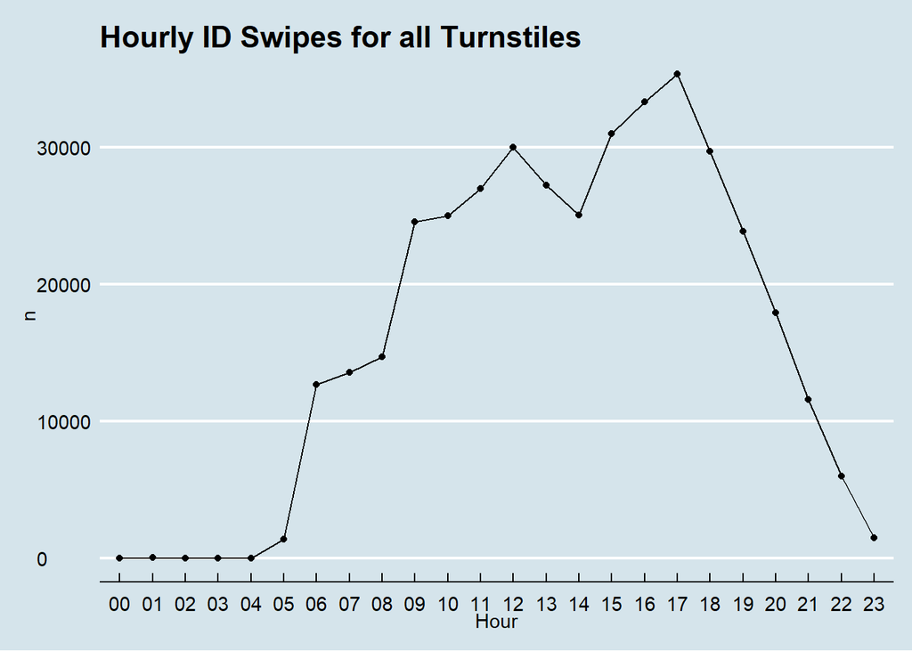

```r
#Group all badge swipes by the hour

hourplot = dplyr::count(SMUSwipe,Hour)

hourplot %>%
  ggplot(aes(x=Hour,y=n, group=1))+
  geom_line()+
  geom_point()+
  theme_economist()+
  scale_colour_economist()+
  ggtitle('Hourly ID Swipes for all Turnstiles')
```

What are the Daily ID Swipes for all Turnstiles?

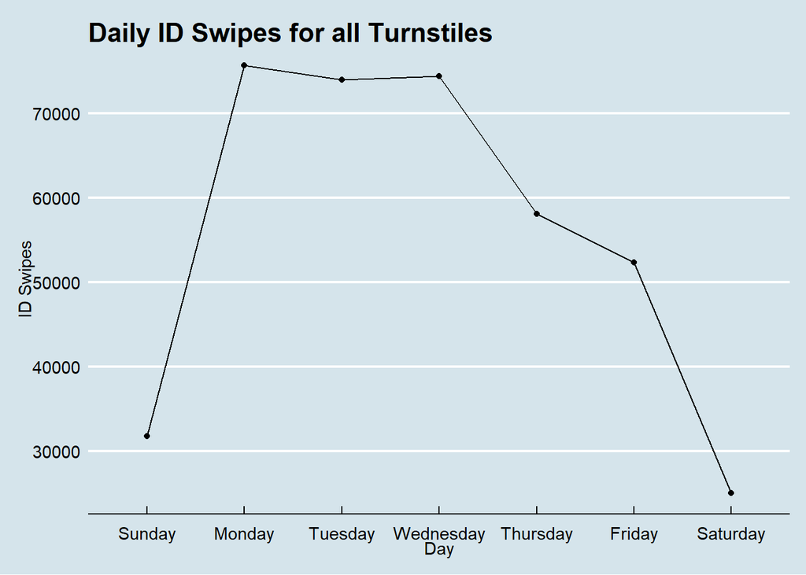

```r
dayCount=dplyr::count(SMUSwipe, Day)
dayCount$Day <- factor(dayCount$Day, levels= c("Sunday", "Monday",
    "Tuesday", "Wednesday", "Thursday", "Friday", "Saturday"))

dayCount=dayCount[order(dayCount$Day), ]

dayCount %>%
  ggplot(aes(x=Day,y=n, group=1))+
  geom_line()+
  geom_point()+
  theme_economist()+
  scale_colour_economist()+
  theme_economist()+
  ggtitle('Daily ID Swipes for all Turnstiles')+
  ylab('ID Swipes')
```

We want to group all ID swipes by 15 minutes (quarter hour).

```r
#Group all ID swipes by 15 minutes (quarter hour)
SMUSwipe$Minutes <- format(SMUSwipe$LDT,"%M")
SMUSwipe$interval_15 <-ifelse(SMUSwipe$Minutes <= 15, 1, ifelse(SMUSwipe$Minutes <= 30, 2, ifelse(SMUSwipe$Minutes <= 45, 3, ifelse(SMUSwipe$Minutes <= 60, 4))))
SMUSwipe$Minutes_15<-paste(SMUSwipe$Hours, SMUSwipe$interval_15, sep=" ")
```

Look at turnstile information.  
Create indivual turnstile data

```r
#Create a dataset for each turnstyle
SMUSwipeTurn1 = SMUSwipe[SMU[,3]=="DEDM (101.1LB)",]
SMUSwipeTurn2 = SMUSwipe[SMU[,3]=="DEDM (101.2LB)",]
SMUSwipeTurn3 = SMUSwipe[SMU[,3]=="DEDM (101.3LB)",]
```

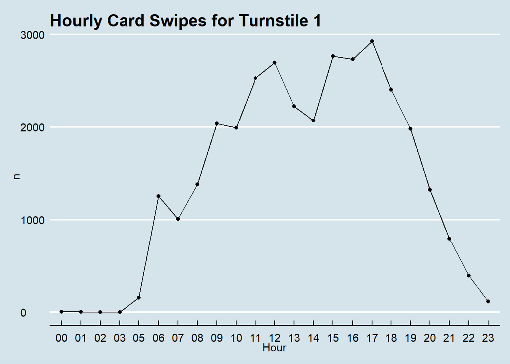

```r
df = dplyr::count(SMUSwipeTurn3, Hours)

HTurn1 = dplyr::count(SMUSwipeTurn1, Hour)
HTurn1 %>%
  ggplot(aes(x=Hour,y=n, group=1))+
  geom_line()+
  geom_point()+
  theme_economist()+
  scale_colour_economist()+
  ggtitle('Hourly Card Swipes for Turnstile 1')
```

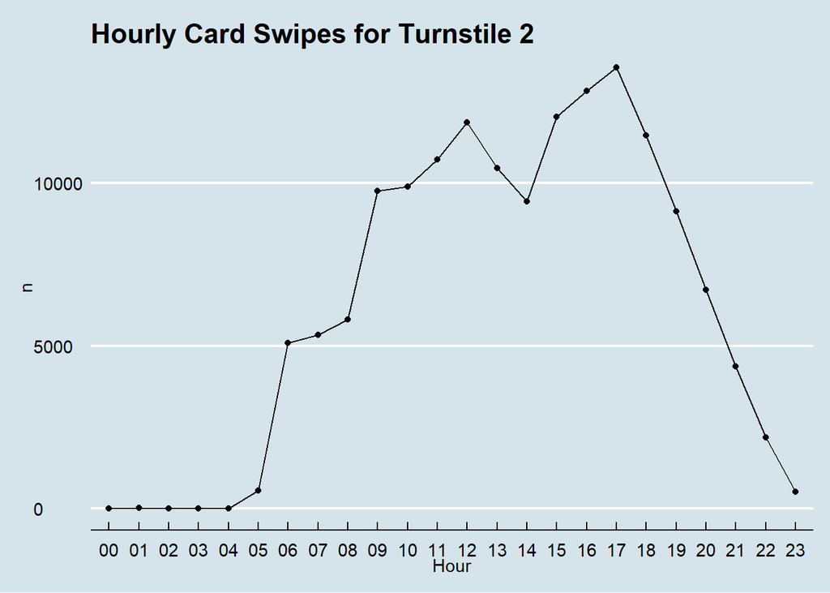

```r
HTurn2 = dplyr::count(SMUSwipeTurn2, Hour)
HTurn2 %>%
  ggplot(aes(x=Hour,y=n, group=1))+
  geom_line()+
  geom_point()+
  theme_economist()+
  scale_colour_economist()+
  ggtitle('Hourly Card Swipes for Turnstile 2')
```

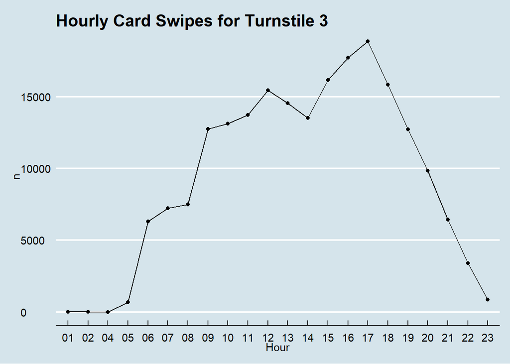

```r
HTurn3 = dplyr::count(SMUSwipeTurn3, Hour)
HTurn3 %>%
  ggplot(aes(x=Hour,y=n, group=1))+
  geom_line()+
  geom_point()+
  theme_economist()+
  scale_colour_economist()+
  ggtitle('Hourly Card Swipes for Turnstile 3')
```

Looks like turnstile 3 gets used more than the others but the pattern of usage looks the same accross each.

This data is anamonized but we can still see who are some of the top users.

```r
#This will count up the times users swiped in.
IDCount = dplyr::count(SMUSwipe, `ID#`)
#Print off the top 10 users ordering nuency in decending order
head(IDCount[order(IDCount$n, decreasing = TRUE),],10)
```

```
## # A tibble: 10 x 2
##    `ID#`     n
##    <dbl> <int>
##  1  1445   429
##  2  1168   413
##  3  1429   390
##  4  1469   369
##  5  1140   361
##  6   912   354
##  7  1778   349
##  8   104   339
##  9   152   338
## 10   214   335
```

Look at some user data.

```r
#Breakdown user numbers
summary(IDCount$n)
```

```
##    Min. 1st Qu.  Median    Mean 3rd Qu.    Max.
##    1.00    7.00   21.00   35.99   48.00  429.00
```

```r
#how many users
dplyr::count(IDCount)
```

```
## # A tibble: 1 x 1
##       n
##   <int>
## 1 10873
```

Convert the hourly data to time series.

```r
#Hourley data
#AnonDataTurnstile <- ts(df$n, frequency=6195, start=c(2019,1), end=c(2020,3))
AnonDataTurnstile = ts(df$n)
head(AnonDataTurnstile)
```

```
## Time Series:
## Start = 1
## End = 6
## Frequency = 1
## [1] 5 3 3 4 6 9
```

Create different data sets for forcasting.

#### Some information on frequency from the web

http://manishbarnwal.com/blog/2017/05/03/time_series_and_forecasting_using_R/

**Daily** data There could be a weekly cycle or annual cycle. So the frequency could be 7 or 365.25.

Some of the years have 366 days (leap years). So if your time series data has longer periods, it is better to use frequency = 365.25. This takes care of the leap year as well which may come in your data.

**Weekly** data There could be an annual cycle. frequency = 52 and if you want to take care of leap years then use frequency = 365.25/7

**Monthly** data Cycle is of one year. So frequency = 12

**Quarterly** data Again cycle is of one year. So frequency = 4

**Yearly** data Frequency = 1

#### How about frequency for smaller interval time series

**Hourly** The cycles could be a day, a week, a year. Corresponding frequencies could be 24, 24 X 7, 24 X 7 X 365.25

**Half-hourly** The cycle could be a day, a week, a year. Corresponding frequencies could be 48, 48 X 7, 48 X 7 X 365.25

**Minutes** The cycle could be hourly, daily, weekly, annual. Corresponding frequencies would be 60, 60 X 24, 60 X 24 X 7, 60 X 24 X 365.25

**Seconds** The cycle could be a minute, hourly, daily, weekly, annual. Corresponding frequencies would be 60, 60 X 60, 60 X 60 X 24, 60 X 60 X 24 X 7, 60 X 60 X 24 X 365.25

```r
MonthCount <- dplyr::count(SMUSwipe, Month)
MonthCount <- ts(MonthCount$n, start = c(2019,1), end = c(2020,3), frequency = 12)
MonthCount
```

```
##        Jan   Feb   Mar   Apr   May   Jun   Jul   Aug   Sep   Oct   Nov   Dec
## 2019 26754 39223 32565 37192 17963 12281 11419 20547 41423 34837 28224 15030
## 2020 24732 35541 13547
```

```r
DayCount <- dplyr::count(SMUSwipe, Date)
DayCount <- ts(DayCount$n, start = c(2019,2), frequency = 365.25)
DayCount
```

```
## Time Series:
## Start = 2019.00273785079
## End = 2020.15263518138
## Frequency = 365.25
##   [1]  235  123  267  172  156  480  584  570  534  552  342  290  705  679  816
##  [16]  752 1439  684  714  768 1783 1882 1642 1619  709  868 2180 1783 1838 1588
##  [31] 1548  642  385 1904 1997 2018 1469 1328  652  953 1924 1947 1809 1396 1422
##  [46]  638 1005 1722 1525 1861 1434 1332  635  952 1895 1677 1853 1300 1382  695
##  [61]  942 1727 1626 1597 1072  804  328  184  452  471  466    1  460  236  456
##  [76] 2053 1823 1723 1557 1416  601  756 1956 1709 1798 1424 1436  607  807 1790
##  [91] 1509 1650 1488 1351  541  795 1857 1780 1939 1445 1407  551  653 1821 1552
## [106] 1395 1148  427  458 1626 1516 1525 1526 1264  575  522 1659 1422 1514 1341
## [121] 1283  590  455 1233  928  794  885  683  465  296  759  595  486  533  439
## [136]    3  186  463  360  492  422  391  213  166  169  517  424  510  368  221
## [151]  186  543  536  506  483  454  284  166  492  523  520  446  480  284  151
```

[output cut: 18 more lines]

```r
SMUSwipe$WeekdayCount<-paste(SMUSwipe$Date, SMUSwipe$Day, sep=" ")
WeekdayCount <- dplyr::count(SMUSwipe, WeekdayCount)
WeekdayCount <- ts(WeekdayCount$n)
WeekdayCount
```

```
## Time Series:
## Start = 1
## End = 421
## Frequency = 1
##   [1]  235  123  267  172  156  480  584  570  534  552  342  290  705  679  816
##  [16]  752 1439  684  714  768 1783 1882 1642 1619  709  868 2180 1783 1838 1588
##  [31] 1548  642  385 1904 1997 2018 1469 1328  652  953 1924 1947 1809 1396 1422
##  [46]  638 1005 1722 1525 1861 1434 1332  635  952 1895 1677 1853 1300 1382  695
##  [61]  942 1727 1626 1597 1072  804  328  184  452  471  466    1  460  236  456
##  [76] 2053 1823 1723 1557 1416  601  756 1956 1709 1798 1424 1436  607  807 1790
##  [91] 1509 1650 1488 1351  541  795 1857 1780 1939 1445 1407  551  653 1821 1552
## [106] 1395 1148  427  458 1626 1516 1525 1526 1264  575  522 1659 1422 1514 1341
## [121] 1283  590  455 1233  928  794  885  683  465  296  759  595  486  533  439
## [136]    3  186  463  360  492  422  391  213  166  169  517  424  510  368  221
## [151]  186  543  536  506  483  454  284  166  492  523  520  446  480  284  151
```

[output cut: 18 more lines]

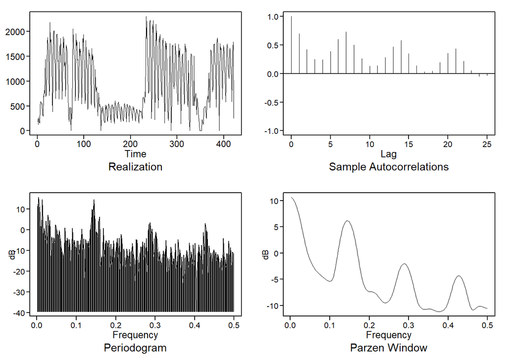

[output not shown]

[output cut: 102 more lines]

```r
plotts.sample.wge(DayCount)
```

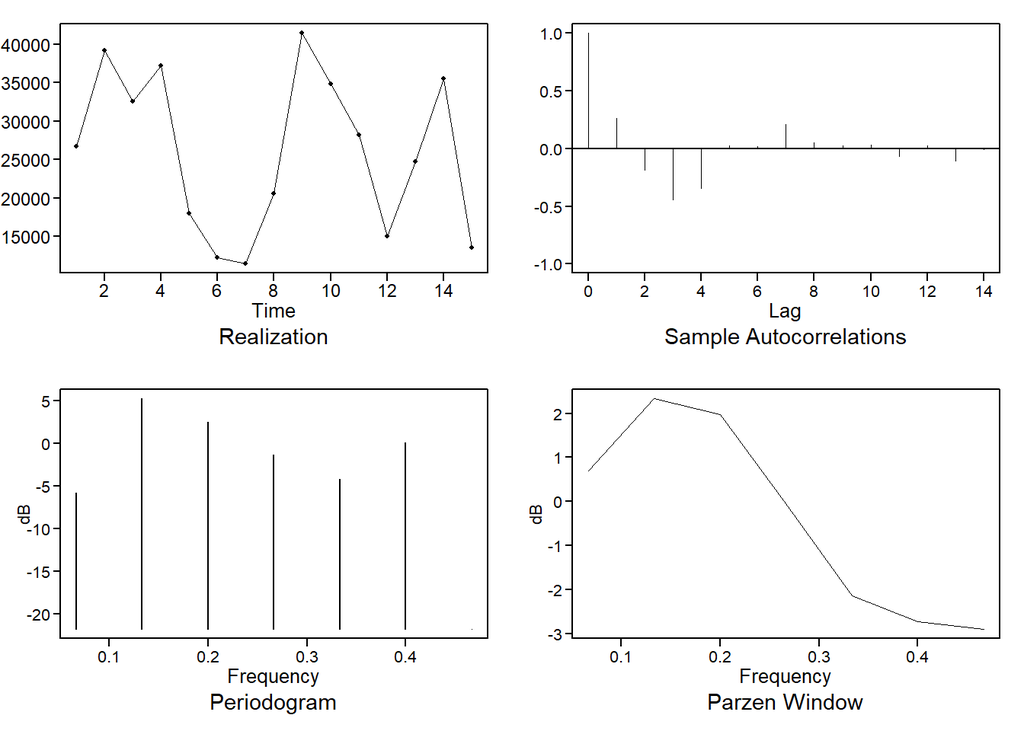

```
## $autplt
##  [1]  1.000000000  0.261454211 -0.188479130 -0.445834792 -0.342773654
##  [6]  0.024137505  0.015989290  0.207816302  0.052793951  0.028515320
## [11]  0.035530323 -0.067522542  0.027542217 -0.103680277 -0.005488726
##
## $freq
## [1] 0.06666667 0.13333333 0.20000000 0.26666667 0.33333333 0.40000000 0.46666667
##
## $db
## [1]  -5.80979143   5.22065184   2.50253719  -1.38490680  -4.21777975
## [6]   0.08182939 -21.84593228
##
## $dbz
## [1]  0.68763129  2.33094720  1.98370063 -0.04846235 -2.13675186 -2.73256000
## [7] -2.90625332
```

```r
plotts.sample.wge(MonthCount)
```

#### Visualize what we have so far.

**Plot the hourly data for all three turnstyles**

```r
#Plot the hourly data
TurnPlotHour=plotts.sample.wge(AnonDataTurnstile)
```

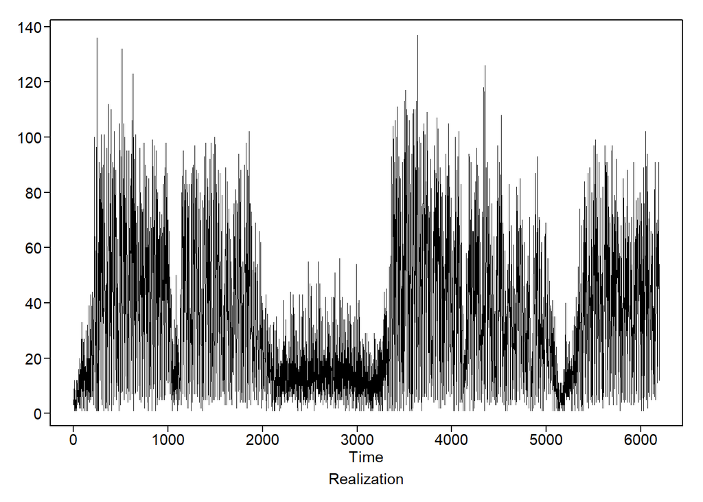

```r
# Test for Conditions
x = AnonDataTurnstile
tswge::plotts.wge(x)
```

```r
plotts.sample.wge(x)
```

[output not shown]

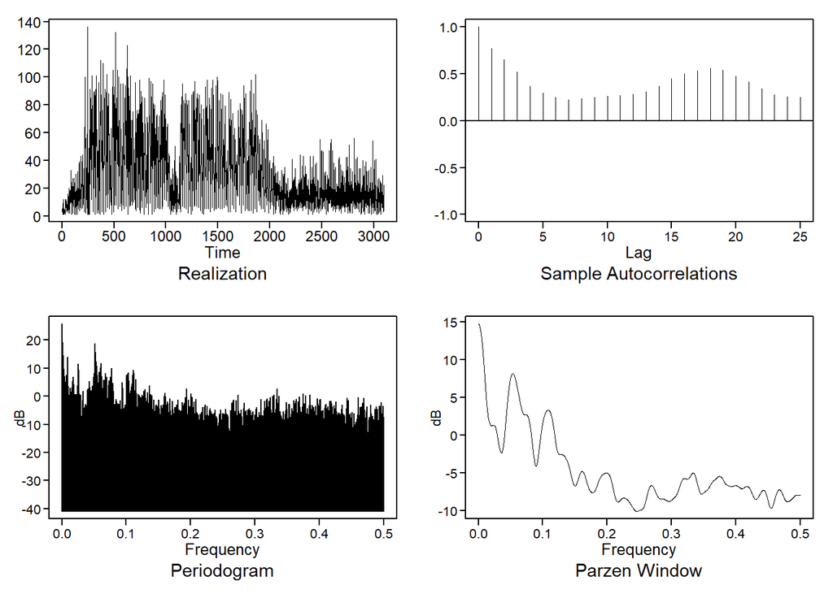

```r
plotts.sample.wge(head(x,length(x)/2))
```

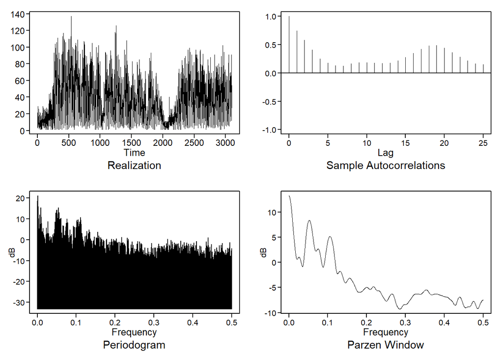

```r
plotts.sample.wge(tail(x,length(x)/2))
```

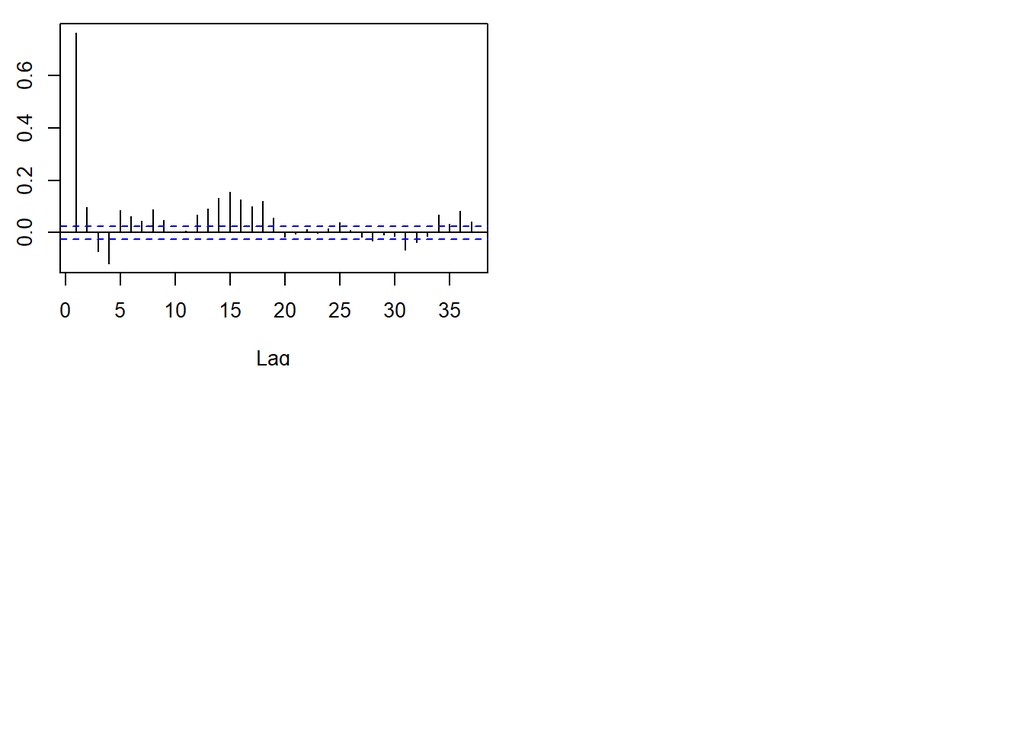

```r
pacf(x)
```

Start ID’ing the data by using the Box and Jeakins method with first differcing the data

```r
#Differcing the data to use the Box and Jeakins method
AnonDataTurnstile_diff=artrans.wge(AnonDataTurnstile,phi.tr=1)
```

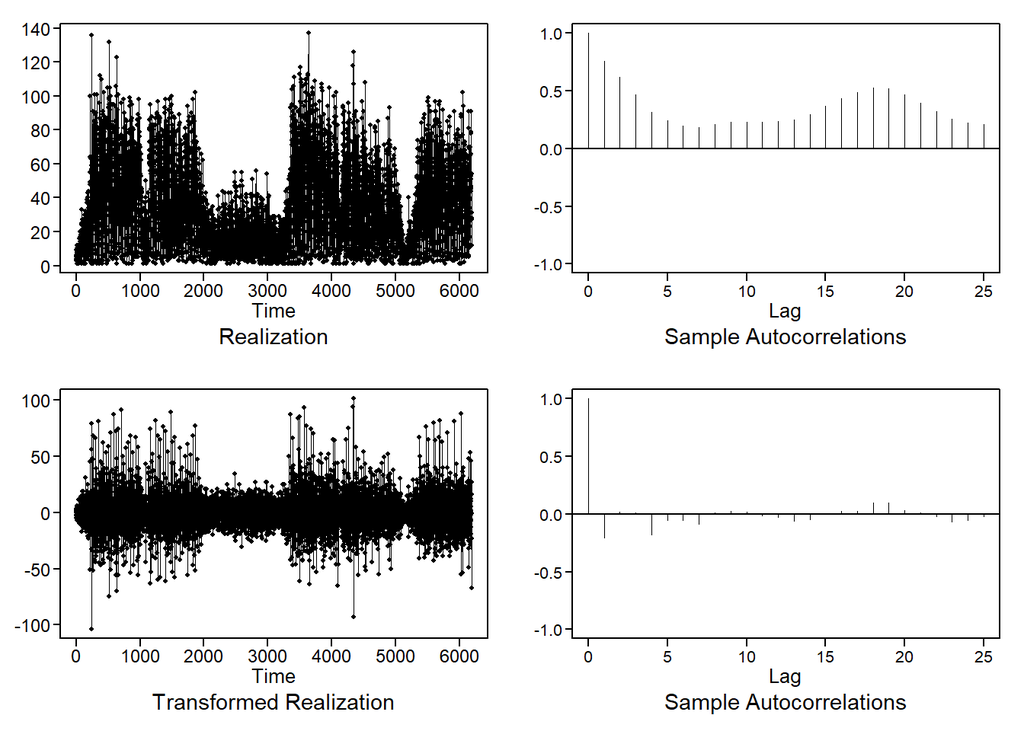

```r
p=4;q=4;s=0
es=tswge::est.arma.wge(x,p=p,q=q)
```

```
##
## Coefficients of Original polynomial:
## 0.1191 0.1304 0.3401 -0.1073
##
## Factor                 Roots                Abs Recip    System Freq
## 1+0.8694B+0.5241B^2   -0.8294+-1.1046i      0.7240       0.3525
## 1-0.6930B              1.4431               0.6930       0.0000
## 1-0.2955B              3.3846               0.2955       0.0000
##
##
```

```r
ase = function(f,x){mean((f - tail(x,length(f)))^2)}
m = tswge::fore.aruma.wge(x,phi = es$phi,theta = es$theta,s=s,n.ahead = 48,lastn = T)
```

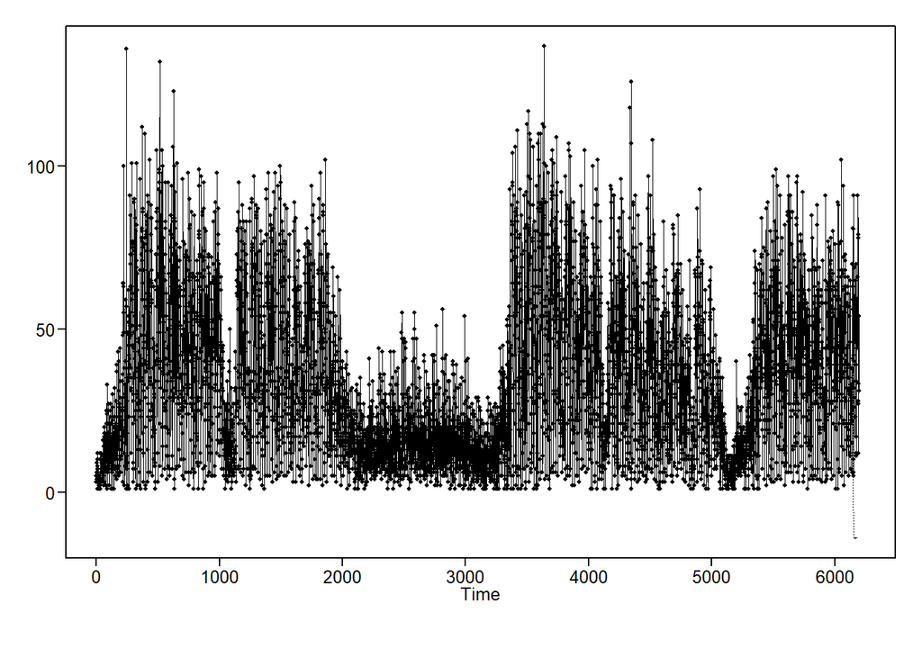

```r
ase = ase(m$f,x)
message("ASE is: ",ase)
```

```
## ASE is: 583.835392223577
```

```r
ase1=ase
```

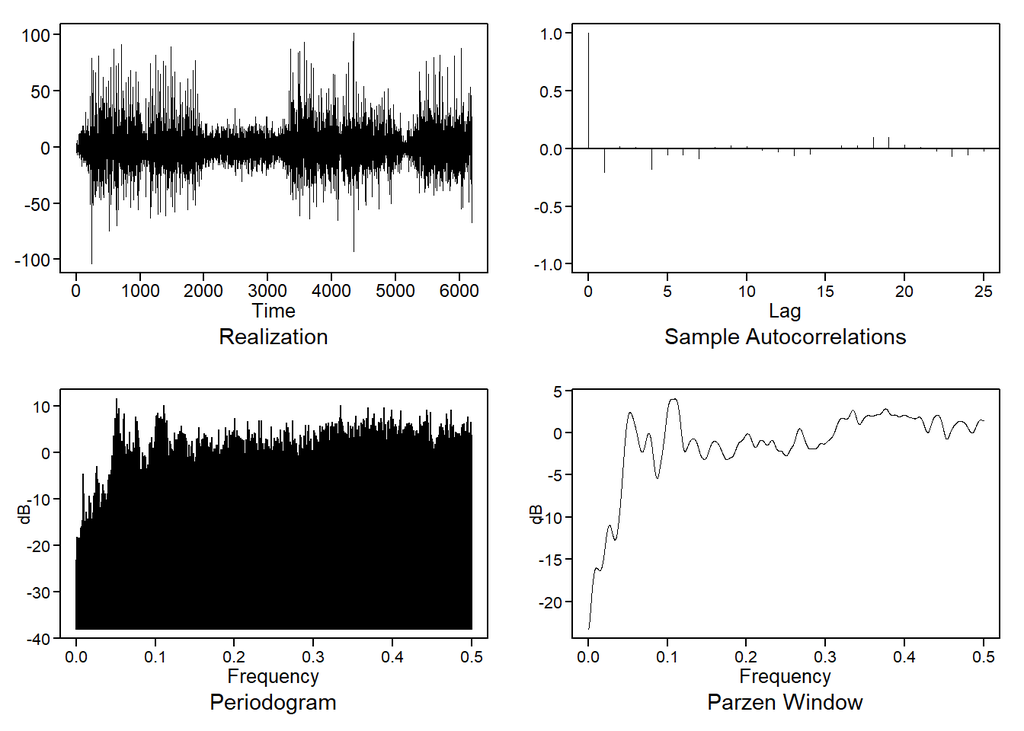

```r
#Plot the differeaced hourly data - diff
plotts.sample.wge(AnonDataTurnstile_diff)
```

Use aic5.wge() to identify estimates of p and q on the differanced data.

```r
#AIC of the hourly data
aic5.wge(AnonDataTurnstile_diff)
```

```
## ---------WORKING... PLEASE WAIT...
##
##
## Five Smallest Values of  aic
```

```
##       p    q        aic
## 14    4    1   5.412712
## 15    4    2   5.413000
## 17    5    1   5.413007
## 18    5    2   5.413308
## 12    3    2   5.418775
```

```r
aic5.wge(AnonDataTurnstile_diff, type = "bic")
```

```
## ---------WORKING... PLEASE WAIT...
##
##
## Five Smallest Values of  bic
```

```
##       p    q        bic
## 14    4    1   5.419232
## 15    4    2   5.420608
## 17    5    1   5.420615
## 18    5    2   5.422002
## 12    3    2   5.425295
```

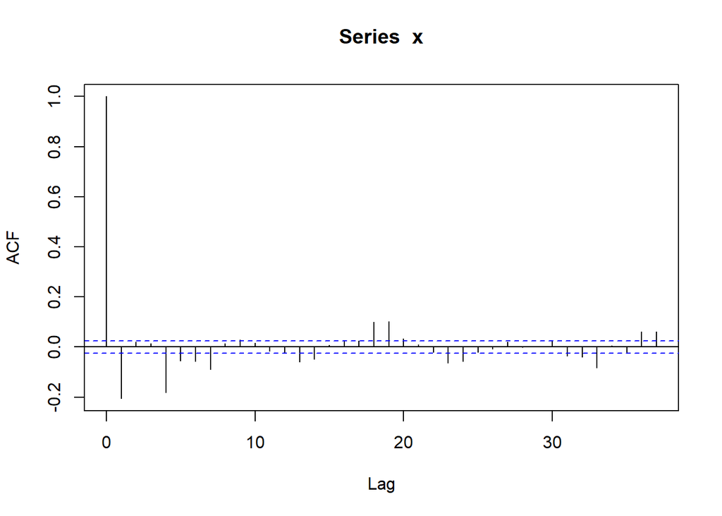

```r
x = AnonDataTurnstile_diff
acf(x)
```

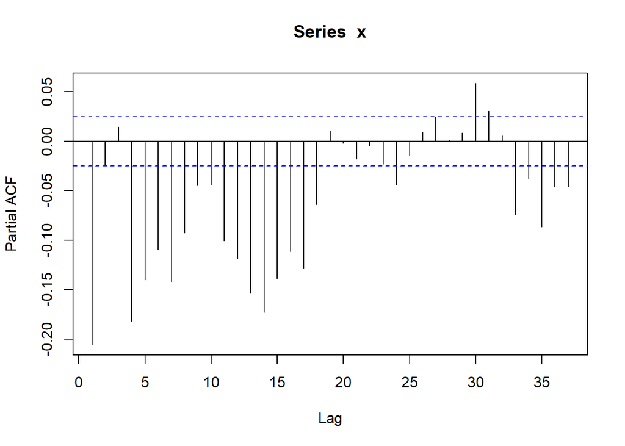

```r
pacf(x)
```

```r
#Use the estimate of p and q to get estimates of the phis and thetas.
est = est.arma.wge(AnonDataTurnstile_diff, p = 4, q = 2)
```

```
##
## Coefficients of Original polynomial:
## 0.6377 0.1247 -0.0120 -0.1937
##
## Factor                 Roots                Abs Recip    System Freq
## 1-1.3922B+0.6059B^2    1.1489+-0.5749i      0.7784       0.0738
## 1+0.7544B+0.3197B^2   -1.1800+-1.3175i      0.5654       0.3662
##
##
```

```r
#Use the estimated model to forecast and so on.
phi=est$phi
phi
```

```
## [1]  0.63773997  0.12473899 -0.01204978 -0.19367013
```

```r
theta=est$theta
theta
```

```
## [1]  1.00540183 -0.03410593
```

```r
wnv=est$avar
wnv
```

```
## [1] 223.7972
```

#### Final ARMA Model

```r
#forcast hour
foreHour_diff=fore.arma.wge((tail(x,length(x)/72)), phi = est$phi, theta = est$theta, lastn = F, n.ahead = 24, limits=F)
```

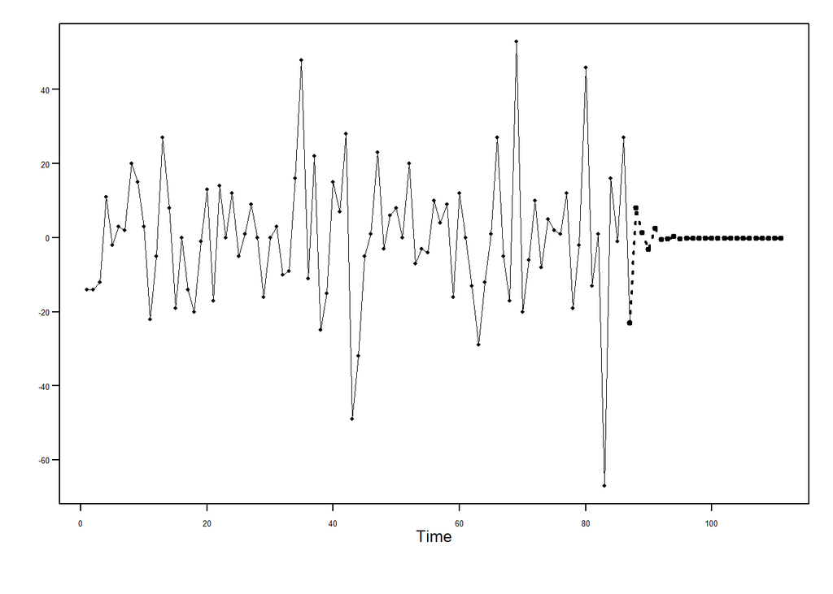

TESTING Look at some of the weather data.

```r
#Conver to a time series.
#WeatherTS <- ts()
#plotts.sample.wge(WeatherTS)
```

####Seasonal Model

Lets see what a Seasonal Model might look like

Look at the data again.

```r
plotts.sample.wge(AnonDataTurnstile)
```

```r
#Factor tables
factAnonData=est.ar.wge(AnonDataTurnstile,p=36,type='burg')
```

```
##
## Coefficients of Original polynomial:
## 0.5782 0.1554 0.0111 -0.1663 0.0308 0.0017 -0.0423 0.0479 0.0433 0.0021 -0.0273 0.0104 -0.0011 0.0305 0.0687 0.0377 0.0107 0.0832 0.0633 -0.0215 -0.0123 0.0121 -0.0123 -0.0128 0.0327 0.0172 -0.0076 -0.0325 0.0107 0.0403 -0.0380 -0.0270 -0.0579 0.0366 -0.0153 0.0820
##
## Factor                 Roots                Abs Recip    System Freq
## 1-0.9899B              1.0102               0.9899       0.0000
## 1-1.8495B+0.9574B^2    0.9658+-0.3340i      0.9785       0.0530
## 1-1.5285B+0.9542B^2    0.8009+-0.6376i      0.9769       0.1070
## 1-1.6815B+0.8968B^2    0.9375+-0.4859i      0.9470       0.0761
## 1-0.9835B+0.8950B^2    0.5495+-0.9030i      0.9460       0.1630
## 1-0.6276B+0.8908B^2    0.3522+-0.9992i      0.9438       0.1961
## 1+0.9427B             -1.0608               0.9427       0.5000
## 1-1.2557B+0.8859B^2    0.7087+-0.7916i      0.9412       0.1338
## 1+1.8507B+0.8854B^2   -1.0451+-0.1930i      0.9410       0.4709
## 1+1.7504B+0.8833B^2   -0.9908+-0.3879i      0.9398       0.4406
## 1+1.5822B+0.8688B^2   -0.9105+-0.5674i      0.9321       0.4113
## 1+0.9000B+0.8659B^2   -0.5197+-0.9406i      0.9305       0.3303
## 1+0.2322B+0.8563B^2   -0.1356+-1.0721i      0.9254       0.2700
## 1+1.3776B+0.8522B^2   -0.8082+-0.7212i      0.9232       0.3840
## 1-0.2916B+0.8499B^2    0.1716+-1.0711i      0.9219       0.2247
## 1+1.1677B+0.8477B^2   -0.6888+-0.8398i      0.9207       0.3593
## 1+0.6209B+0.8320B^2   -0.3731+-1.0309i      0.9121       0.3053
## 1-1.7853B+0.8131B^2    1.0979+-0.1568i      0.9017       0.0226
## 1-0.0094B+0.7257B^2    0.0065+-1.1739i      0.8519       0.2491
##
##
```

```r
factor.wge(c(rep(0,35),1)) #(1-B^36)
```

```
##
## Coefficients of Original polynomial:
## 0.0000 0.0000 0.0000 0.0000 0.0000 0.0000 0.0000 0.0000 0.0000 0.0000 0.0000 0.0000 0.0000 0.0000 0.0000 0.0000 0.0000 0.0000 0.0000 0.0000 0.0000 0.0000 0.0000 0.0000 0.0000 0.0000 0.0000 0.0000 0.0000 0.0000 0.0000 0.0000 0.0000 0.0000 0.0000 1.0000
##
## Factor                 Roots                Abs Recip    System Freq
## 1-1.9696B+1.0000B^2    0.9848+-0.1736i      1.0000       0.0278
## 1-1.0000B+1.0000B^2    0.5000+-0.8660i      1.0000       0.1667
## 1+1.0000B             -1.0000               1.0000       0.5000
## 1+1.5321B+1.0000B^2   -0.7660+-0.6428i      1.0000       0.3889
## 1-1.2856B+1.0000B^2    0.6428+-0.7660i      1.0000       0.1389
## 1-1.7321B+1.0000B^2    0.8660+-0.5000i      1.0000       0.0833
## 1-1.5321B+1.0000B^2    0.7660+-0.6428i      1.0000       0.1111
## 1-0.3473B+1.0000B^2    0.1736+-0.9848i      1.0000       0.2222
## 1+1.2856B+1.0000B^2   -0.6428+-0.7660i      1.0000       0.3611
## 1+0.3473B+1.0000B^2   -0.1736+-0.9848i      1.0000       0.2778
## 1-1.0000B              1.0000               1.0000       0.0000
## 1+1.0000B+1.0000B^2   -0.5000+-0.8660i      1.0000       0.3333
## 1-1.8794B+1.0000B^2    0.9397+-0.3420i      1.0000       0.0556
## 1-0.6840B+1.0000B^2    0.3420+-0.9397i      1.0000       0.1944
## 1+0.0000B+1.0000B^2    0.0000+-1.0000i      1.0000       0.2500
## 1+0.6840B+1.0000B^2   -0.3420+-0.9397i      1.0000       0.3056
## 1+1.9696B+1.0000B^2   -0.9848+-0.1736i      1.0000       0.4722
## 1+1.7321B+1.0000B^2   -0.8660+-0.5000i      1.0000       0.4167
## 1+1.8794B+1.0000B^2   -0.9397+-0.3420i      1.0000       0.4444
##
##
```

```r
#factor.wge(c(0,0,0,0,0,0,0,0,1)) #(1-B^9)
```

Use artrans.wge() to get y. This is to remove the seasonality in the data.

```r
#Use artrans.wge() to get y. This is to remove the seasonality in the data.
#In this data we are checking for nine months weekley number (36).
y = artrans.wge(AnonDataTurnstile,phi.tr=c(c(rep(0,35),1)))
```

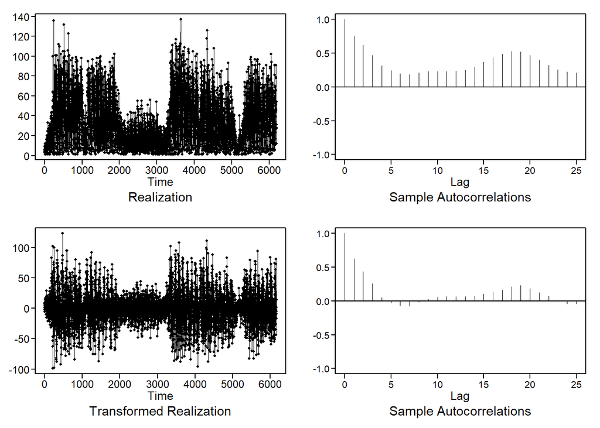

```r
# y is the transformed data
#aic5.wge(y,p=0:15,q=0:6,type='bic') #picked a ARMA(9,6)
```

```r
AnonDataTurnstile.est155=est.arma.wge(y,p=9, q=6)
```

```
##
## Coefficients of Original polynomial:
## 0.6868 -0.1084 0.2612 -0.4556 -0.5855 0.4482 0.0591 0.0516 -0.1038
##
## Factor                 Roots                Abs Recip    System Freq
## 1-1.5829B+0.9874B^2    0.8015+-0.6085i      0.9937       0.1033
## 1+0.6782B+0.9241B^2   -0.3670+-0.9734i      0.9613       0.3074
## 1+0.8313B             -1.2030               0.8313       0.5000
## 1-1.2378B+0.4377B^2    1.4140+-0.5342i      0.6616       0.0575
## 1+0.6244B+0.3126B^2   -0.9987+-1.4838i      0.5591       0.3443
##
##
```

```r
AnonDataTurnstile.est155$phi
```

```
## [1]  0.68679676 -0.10839164  0.26121944 -0.45561104 -0.58554610  0.44821701
## [7]  0.05911743  0.05155061 -0.10377254
```

```r
AnonDataTurnstile.est155$theta
```

```
## [1]  0.11103637 -0.19253158  0.16064671 -0.24447955 -0.78060402  0.04999182
```

```r
AnonDataTurnstile.est155$avar
```

```
## [1] 411.9237
```

```r
mean(AnonDataTurnstile)
```

```
## [1] 33.37821
```

#### Final Seasonal Model

```r
seasonFore=fore.aruma.wge(AnonDataTurnstile,phi=c(factAnonData$phi),s=36,n.ahead=48,limits=F)
```

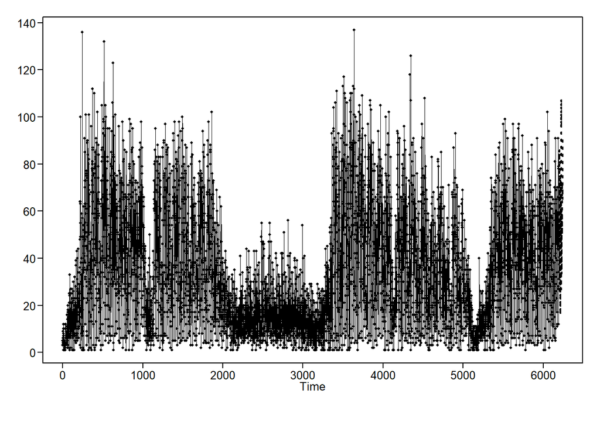

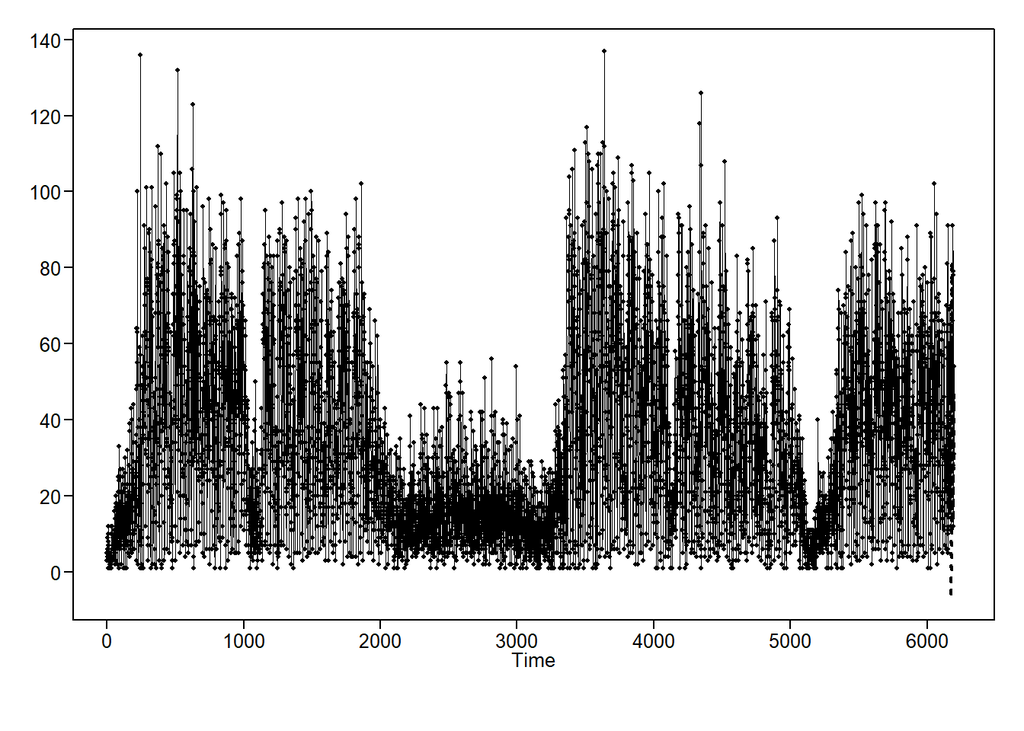

```r
seasonFore$f

fore.aruma.wge(AnonDataTurnstile,phi=c(factAnonData$phi),s=36,n.ahead=48,plot=T,lastn=T,limits=F)
```

```r
p=15;q=9;s=3
es=tswge::est.arma.wge(x,p=p,q=q)
```

```
##
## Coefficients of Original polynomial:
## -0.6601 -0.2037 0.0504 0.2138 -0.5360 -0.8913 -0.3991 -0.1656 0.1943 -0.1544 -0.2146 -0.2537 -0.2508 -0.2023 -0.0809
##
## Factor                 Roots                Abs Recip    System Freq
## 1+1.8705B+0.9577B^2   -0.9765+-0.3009i      0.9786       0.4524
## 1+0.1990B+0.9551B^2   -0.1042+-1.0179i      0.9773       0.2662
## 1-1.5381B+0.9421B^2    0.8163+-0.6286i      0.9706       0.1044
## 1-1.7387B+0.8680B^2    1.0016+-0.3859i      0.9317       0.0585
## 1+0.7397B+0.7439B^2   -0.4971+-1.0474i      0.8625       0.3205
## 1-0.4321B+0.5335B^2    0.4050+-1.3078i      0.7304       0.2022
## 1+0.9666B+0.4592B^2   -1.0525+-1.0344i      0.6777       0.3764
## 1+0.5933B             -1.6856               0.5933       0.5000
##
##
```

```r
ase = function(f,x){mean((f - tail(x,length(f)))^2)}
m = tswge::fore.aruma.wge(x,phi = es$phi,theta = es$theta,s=s,n.ahead = 48,lastn = T, limits = F)
```

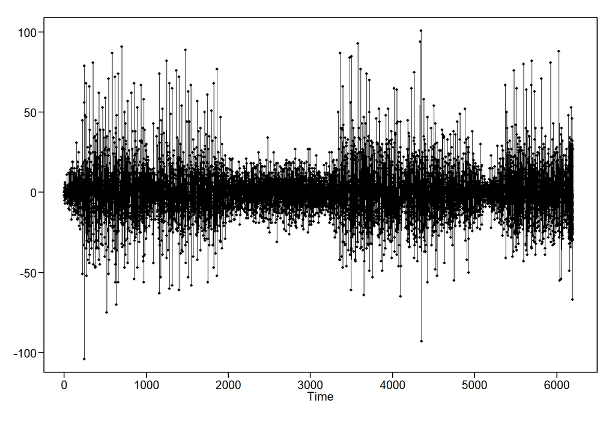

```r
ase = ase(m$f,x)
message("ASE is: ",ase)
```

```
## ASE is: 1063.06802306848
```

```r
ase2=ase
```

```r
#Trying the forcasting package

IDSwipes <- read_csv("DedmanDailySwipe.csv")
```

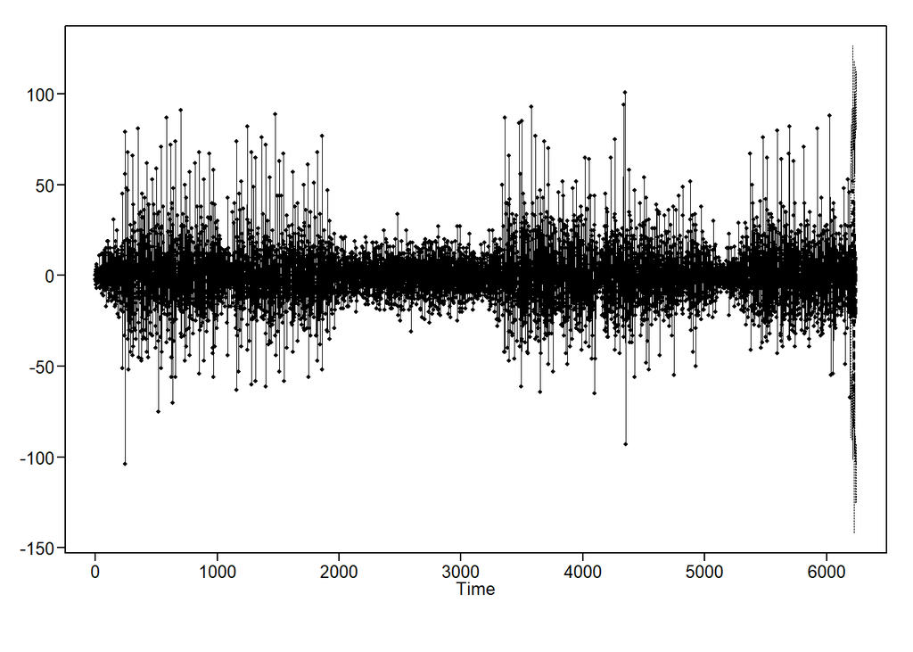

```r
#Convert to a time series at 365 days
#IDSwipes = ts(IDSwipes$IDSwipes, start = c(2019,2), frequency = 365)

IDSwipes = ts(IDSwipes$IDSwipes)

#Divide dataset into training and test set.  The last 36 months in the test set.
IDSwipes1st = (IDSwipes[1:100])
IDSwipes2nd = (IDSwipes[101:421])

AnonDataTurnstile.f = auto.arima(IDSwipes, stepwise=FALSE, approximation=FALSE, stationary = FALSE, seasonal = TRUE, trace = FALSE,max.p = 13,max.q = 5,max.P = 13,max.Q = 5)

f=fore.aruma.wge(x, phi = c(1.195, 0.0297, 0.0842, 0.187, -1.169, .524, .076, .217, -.197, -.011,.023,-.033,.078,-.075,.0318), theta = c(.614, .302, .305, .624, -.993), s = 36, n.ahead = 48, plot = TRUE)
```

```r
DayForcast=forecast::forecast(AnonDataTurnstile.f, h=7, level = 95)
DayForcast
```

```
##     Point Forecast      Lo 95    Hi 95
## 422       323.9133 -419.59031 1067.417
## 423       558.9822 -340.25921 1458.224
## 424      1131.4703  193.76856 2069.172
## 425      1302.1159  363.80427 2240.427
## 426      1192.2846  252.90445 2131.665
## 427       930.7972  -11.69285 1873.287
## 428       785.1916 -182.57260 1752.956
```

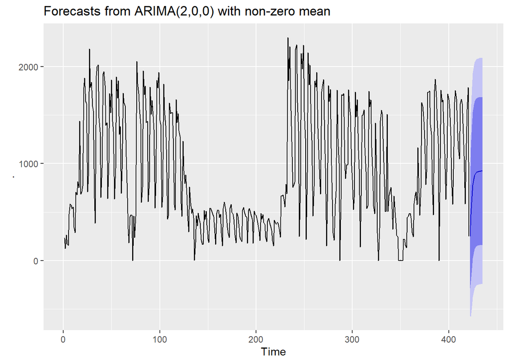

```r
# Automatic ARIMA forecasts
IDSwipes %>%
  auto.arima() %>%
  forecast(h=14) %>%
  autoplot()
```

#### NN

Fit the model with the default settings forcasting 14 days out.

```r
df <- read_csv("DedmanDailySwipe.csv")
#Convert to a time series at 365 days
df = ts(df$IDSwipes, start = c(2019,2), frequency = 365)

df
```

```
## Time Series:
## Start = c(2019, 2)
## End = c(2020, 57)
## Frequency = 365
##   [1]  235  123  267  172  156  480  584  570  534  552  342  290  705  679  816
##  [16]  752 1439  684  714  768 1783 1882 1642 1619  709  868 2180 1783 1838 1588
##  [31] 1548  642  385 1904 1997 2018 1469 1328  652  953 1924 1947 1809 1396 1422
##  [46]  638 1005 1722 1525 1861 1434 1332  635  952 1895 1677 1853 1300 1382  695
##  [61]  942 1727 1626 1597 1072  804  328  184  452  471  466    1  460  236  456
##  [76] 2053 1823 1723 1557 1416  601  756 1956 1709 1798 1424 1436  607  807 1790
##  [91] 1509 1650 1488 1351  541  795 1857 1780 1939 1445 1407  551  653 1821 1552
## [106] 1395 1148  427  458 1626 1516 1525 1526 1264  575  522 1659 1422 1514 1341
## [121] 1283  590  455 1233  928  794  885  683  465  296  759  595  486  533  439
## [136]    3  186  463  360  492  422  391  213  166  169  517  424  510  368  221
## [151]  186  543  536  506  483  454  284  166  492  523  520  446  480  284  151
```

[output cut: 18 more lines]

```r
fit.mlp.Dedman = mlp(df)

fit.mlp.Dedman
```

```
## MLP fit with 5 hidden nodes and 20 repetitions.
## Series modelled in differences: D1.
## Univariate lags: (188,193,199,226,295,351)
## Forecast combined using the median operator.
## MSE: 9276.6337.
```

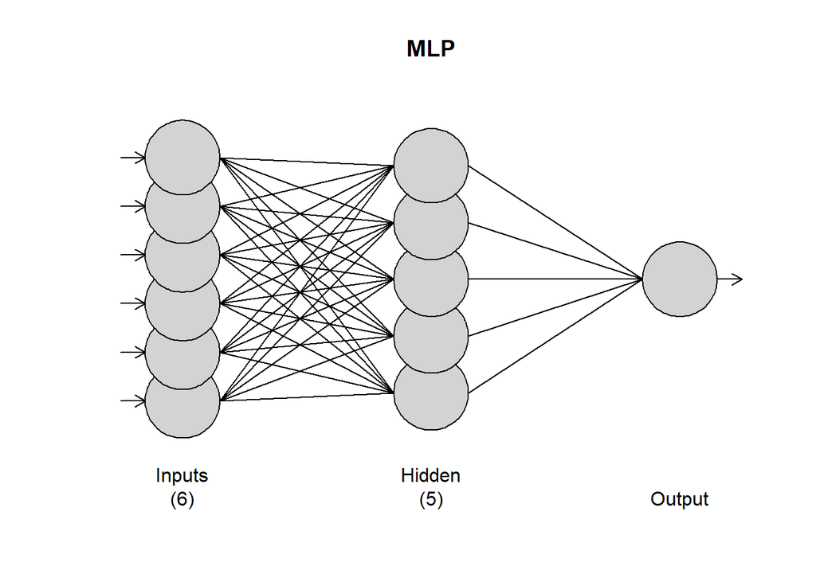

```r
plot(fit.mlp.Dedman)
```

```r
fore.mlp.Dedman = forecast(fit.mlp.Dedman, h = 14)
fore.mlp.Dedman
```

```
##           Point Forecast
## 2020.1562       101.4598
## 2020.1589      -249.5635
## 2020.1616       384.1492
## 2020.1644       284.2628
## 2020.1671      1174.1406
## 2020.1699      1216.2606
## 2020.1726      1173.2811
## 2020.1753      -425.4634
## 2020.1781      -897.4050
## 2020.1808      -985.8185
## 2020.1836      -872.1347
## 2020.1863     -1152.7884
## 2020.1890        34.5803
## 2020.1918      -486.9913
```

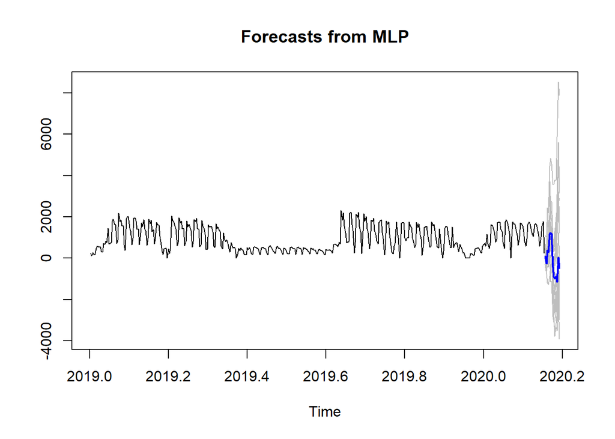

```r
plot(fore.mlp.Dedman)
```

```r
ASE_Dedman_NNid = mean((df[((421-14)+1):421] - fore.mlp.Dedman$mean)^2)
ASE_Dedman_NNid
```

```
## [1] 2188395
```